# Testing the emulators for JULES-ES-1.0

3. Crown copyright, Met Office

Code to run analysis and generate figures for McNeall et al. (2023?) “Constraining the carbon cycle in JULES-ES-1.0”.

This analysis tests the quality of the gaussian process emulators used to interpolate both waves of JULES runs. These figures can be found in appendix C of the paper.

[output not shown]

# 1 Entire data set

This binds together level1a constrained data from wave01 with the training set from wave01.

## 1.1 Entire anomaly ensemble (select outputs)

## 1.2 PMAE summary of level 1 and entire ensemble

## 1.3 Leave-one-out analyses of emulator prediction accuracy

# 2 So further constraining to level 2 can be associated back to the top level.

## 2.1 Emulator accuracy of members from wave 00 and wave 01 that pass level 2 (AW’s) constraints

We see that the error stats for some of the outputs from wave01 are worse, but there are many more ensemble members that lie within the constraints for wave 01.

“pmae” is “proportional mean absolue error”, which is the mean absolute error expressed as a percentage of the original (minimally constrained) ensemble range in that output.

Good news is, the emulators are more accurate for wave01.

Many of the wave01 predictions are closer to the horizontal line, and therefore more accurate predictions.

None of the predictions are outside the uncertainty bounds, which suggests they are overconservative (should be smaller).

Looking at the proportional mean absolute error (pmae), expressed in percent, we can see that it doesn’t improve much for the whole ensemble, but *does* improve significantly for the subset of ensemble members that fall within AW’s constraints from the first ensemble (marked "_sub").

```
     pmae_wave00 pmae_wave01 pmae_wave00_sub pmae_wave01_sub
[1,] 5.026718    4.925463    7.597557        4.290467
[2,] 4.229873    3.839263    4.757751        3.803783
[3,] 3.612841    3.612925    4.696408        3.638359
[4,] 4.225317    4.445669    4.72662         3.679239
```

## 2.2 Subset analysis

## 2.3 How well do we predict the constrained members?

Plotting the predictions, with a special focus on the constrained members. The message is, to do better on predicting the members, we need to do better with the cVeg emulator. Many of its members are way too low, and this is dragging down the predictions. Some are false positives though. Could we plot Loo error vs the parameters?

```
Loaded dtw v1.22-3. See ?dtw for help, citation("dtw") for use in publication.
```

```
[1] 0.4166667
[1] 0.5882351
```

## 2.4 A better emulator for cVeg

It’s clear from other experiments that a major barrier to a good prediction of a constrained is a better emulator for cVeg.

Some experiments to create a better emulator

[output not shown]

[output cut: 13 more lines]

[output not shown]

How good are the leave-one-out predictions of the transformed data?

It appears the square root transformation outperforms the standard - but mostly at low values (which we don’t think are realistic).

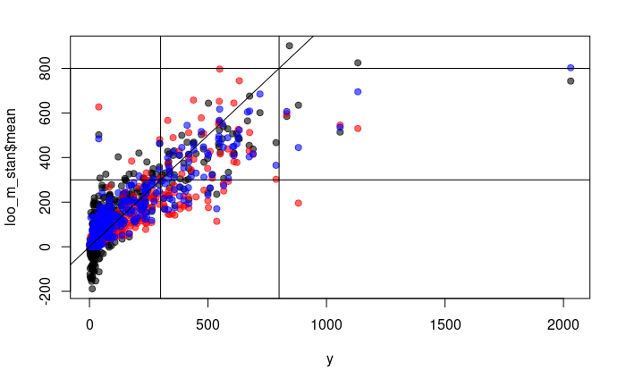

```
$mae
[1] 85.76178

$pmae
[1] 4.225332

$maxerr
[1] 463.0453

$mae
[1] 67.80361

$pmae
[1] 3.340564

$maxerr
[1] 729.1823

$mae
[1] 59.94145

$pmae
[1] 2.95321

$maxerr
[1] 445.0282
```

```
[1] 0.4166667
[1] 0.5882351
[1] 0.3755869
[1] 0.5460748
[1] 0.2650739
[1] 0.4190645
```

```
      0   1
  0 309  14
  1  14  24

      0   1
  0 312  11
  1  23  15

      0   1
  0 313  10
  1  18  20
```

[output not shown]

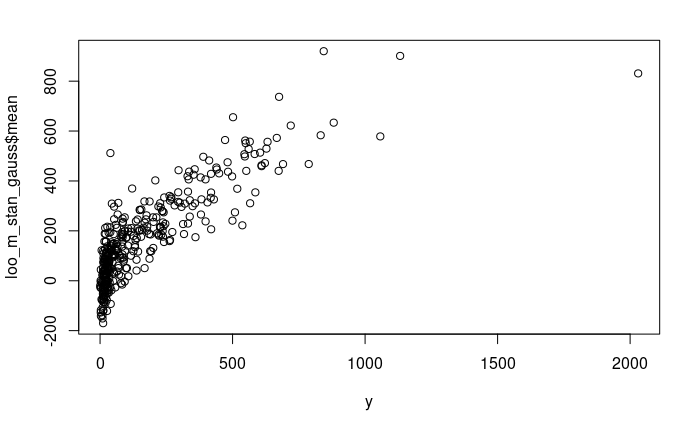

[output not shown]

[output cut: 76 more lines]

[output not shown]

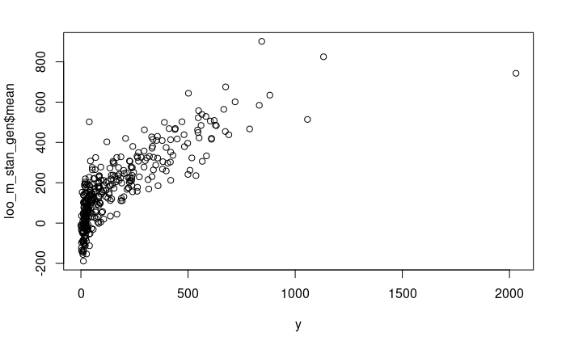

[output not shown]

[output cut: 76 more lines]

[output not shown]

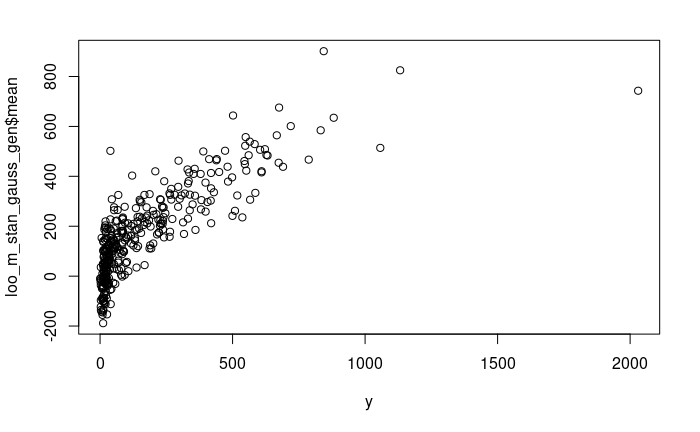

[output not shown]

[output cut: 76 more lines]

[output not shown]

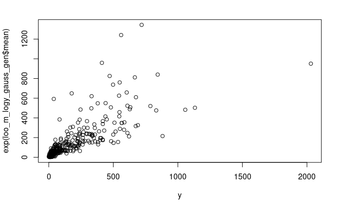

[output not shown]

[output cut: 76 more lines]

[output not shown]

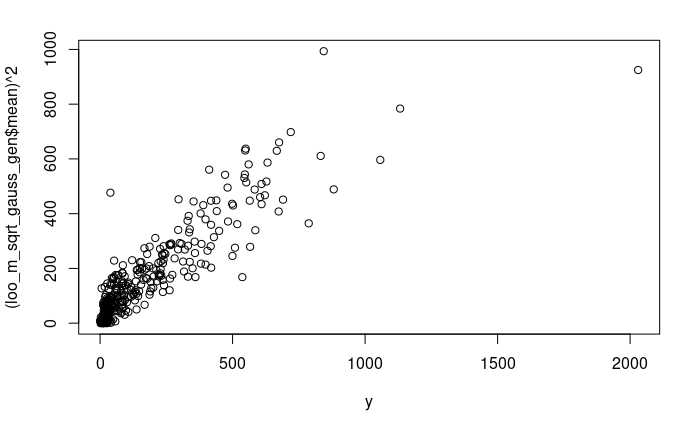

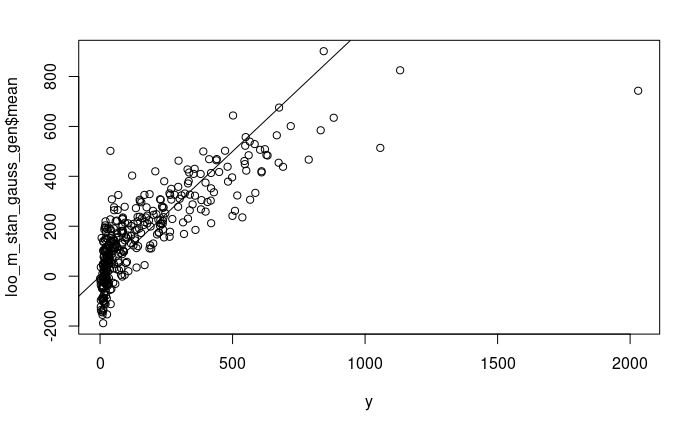

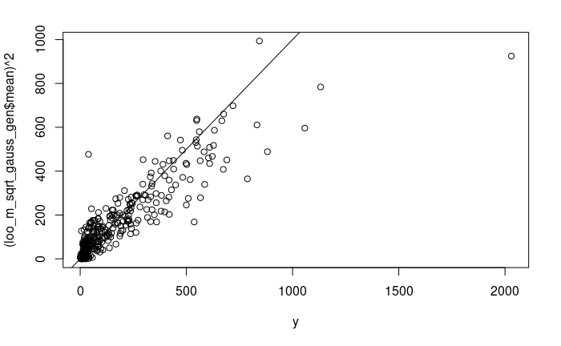